# 2.3.2 LNCaP LOY vs sgCTRL — RNA-seq extended (robustness layer)

# Overview

**Extended** LNCaP LOY-vs-sgCTRL analysis — robustness layer on top of the canonical base report (`2.3.1_rnaseq_LNCaP_base.Rmd`). Same count matrix, same samples, additional sanity-checks and alternative framings designed to answer “would the conclusions change if we’d made different statistical choices?”.

LNCaP is an androgen-dependent prostate adenocarcinoma line carrying an **AR T878A** ligand-binding-domain mutation, biallelic **PTEN deletion** (constitutive PI3K/AKT activation), and wild-type **TP53** — a different oncogenic context from HT1080 (NRAS Q61K fibrosarcoma) and A549 (KRAS G12S lung adenocarcinoma). **No PARENTAL arm** was collected for LNCaP, so the **pooled Y+** design (LOY vs PARENTAL+sgCTRL) used in the HT1080/A549 extended notebooks is not available here. DE-centric sections cover **two designs side-by-side**: paired (sgCTRL by passage) and unpaired (sgCTRL without the passage block).

**Counts pipeline.** Counts come from `STAR_v2_PARfix/MAY_2026_LNCAP_LOY/` — a PAR-Y-masked STAR realignment + featureCounts re-quantification done specifically to recover chrX-PAR reads that the original MAY_2026 STAR run silently dropped at multi-mapper filtering. MSY (true chrY) counts are unchanged; PAR1/PAR2 counts (SHOX, CSF2RA, SLC25A6, etc.) are now non-zero. Y-region annotation lives in §1.4.5; the Y/PAR-retaining volcano is §4.0; the §11 LOY-transcriptomics summary now produces real PAR signature scores.

1. **Filter-threshold sensitivity** (§2). Sweep `MIN_COUNT ∈ {50, 100, 200}` on the paired design (the design of record), report DEG and Hallmark NES concordance across thresholds, pick the threshold used downstream. The design-choice axis (paired / unpaired) is addressed in §4/§5/§6 and the §10 robustness summary, where it actually shapes the result.
2. **voom diagnostics + sample weights** (§3). Mean-variance plot and `voomWithQualityWeights` for sample-reliability auditing on 3v3 data (paired, design-of-record).
3. **Effect-size-aware DE with `treat()`** (§4). Tested against the lfc threshold across both designs.
4. **edgeR quasi-likelihood cross-check** (§5). `glmQLFTest` as a second statistical framework across both designs.
5. **`camera` gene-set testing** (§6). Competitive, correlation-aware side-by-side with fgsea, across both designs.
6. **Sex-chromosome homologs / Y-linked paralog deep-dive** (§7). KDM5D/C, UTY/KDM6A, DDX3Y/X, RPS4Y1/X, EIF1AY/X, ZFY/X, TMSB4Y/X, USP9Y/X, PRKY/X, NLGN4Y/X — dosage compensation analysis (paired, design-independent at the per-sample level).
7. **Sample-level pathway scoring** (§8). GSVA / ssGSEA Hallmark, PROGENy, decoupleR-PROGENy, and custom LOY/PRC2/chrY signatures. Sample scoring is design-independent; the LM significance test at the end is run across both designs.
8. **lpWGS copy-number integration** (§9). Gene-level CN from LNCaP QDNAseq on T2T-CHM13, DEG annotation (canonical paired), chromosome-arm shifts, CN-flagged DEG sensitivity rerun across both designs in §9.9, Y-loss confirmation panel (lpWGS + RNA).
9. **Robustness summary** (§10). Combined DEG table across all statistical pipelines × both designs + CN + paralog flags; “confident DEG” call.

Notation: LNCaP = AR T878A / PTEN-null prostate adenocarcinoma; CTRL = sgRNA non-targeting control (Y+); LOY = Y-chromosome–targeting sgRNA (Y−). No PARENTAL arm was collected; the LOY-vs-sgCTRL contrast is the only design available, in either paired (treatment + passage) or unpaired (treatment-only) form.

# 1. Setup

## 1.1 Load packages

## 1.2 Paths and figure helper

## 1.3 Sample metadata + counts

LNCaP Sample Summary (n=6)

| treatment | n | replicates |
| --- | --- | --- |
| CTRL | 3 | 12, 13, 14 |
| LOY | 3 | 12, 13, 14 |

```
## Loaded 78899 genes across 6 samples
```

## 1.4 Build DGEList scaffold (no filtering yet)

```
## Genes with full annotation: 24356
```

## 1.4.5 Y-region annotation (PAR1 / PAR2 / MSY-Yp / MSY-Yq)

GRCh38 PAR coordinates (Ensembl/GENCODE). PAR genes are annotated on chrX only (chrY PAR positions are masked at the annotation level), so PAR identification scans chrX. MSY = remaining chrY genes (non-PAR), split into Yp / Yq by the chrY centromere midpoint (~10.43 Mb, UCSC).

Two filter sets are exposed downstream:

- **`chrY_gene_ids`** (MSY only) — stripped from the DGEList before differential expression (§2 filter sweep, §4 treat-helpers). PAR genes stay so they get logFC + FDR like every other gene in §4.1+ volcanos.
- **`excluded_gene_ids`** (chrY ∪ PAR) — stripped at every pathway-input boundary: `prep_ranks()` in the sweep chunk; camera voom rows in §6; ssGSEA / PROGENy / decoupleR lcpm matrices in §8; CN-sensitivity rerun in §9.9 (via `prep_ranks`). Camera/GSVA/decoupleR are gene-set / TF tests where PAR LOY signal would distort the result (it’s library- composition artefact, not biology).

```
## Y-region panel: 113 genes  [PAR1=20, PAR2=3, MSY-Yp=35, MSY-Yq=55]
```

```
## Exclusion set for pathway analyses: 113 genes (chrY ∪ PAR)
```

## 1.5 Multi-design DE infrastructure

The robustness sections (§2 filter sweep, §4 treat, §5 edgeR-QL, §6 camera, §8.6 LM tests, §9.9 CN-flagged rerun, §10 robustness summary) all run the same two DE designs side-by-side. Defining the design specifications once keeps the downstream code mechanical. (HT1080 and A549 also carry a third “pooled” Y+ design that pools PARENTAL + sgCTRL as the Y+ reference — that design is unavailable here because LNCaP has no PARENTAL arm.)

```
## Design specs registered: paired, unpaired
```

# 2. Filter-threshold sensitivity sweep

`filterByExpr(min.total.count = ?)` with `MIN_COUNT ∈ {50, 100, 200}`. For each, build the LOY+CTRL working set, refit paired limma–voom DE, capture DEG counts, and run fgsea on Hallmark.

```
## Loading Hallmark for sweep...
```

```
##
## --- MIN_COUNT = 50 ---
##   After filter: 14659 genes; 6 samples
##
## --- MIN_COUNT = 100 ---
##   After filter: 14101 genes; 6 samples
##
## --- MIN_COUNT = 200 ---
##   After filter: 13392 genes; 6 samples
```

## 2.1 Summary table

Filter-threshold sweep — tested genes, DEGs, GSEA hits

| MIN_COUNT | n_tested | n_FDR_0.05 | n_FDR_0.05_&_\|lfc\|>0.75 | n_hallmark_padj_0.05 |
| --- | --- | --- | --- | --- |
| 50 | 14659 | 184 | 61 | 21 |
| 100 | 14101 | 188 | 63 | 21 |
| 200 | 13392 | 193 | 64 | 21 |

## 2.2 Gene-set overlap across thresholds

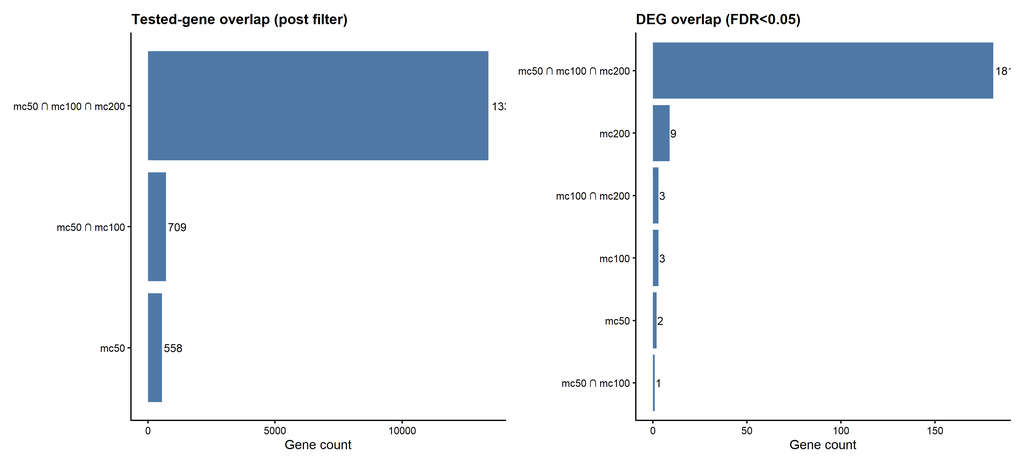

```
## Saved: sweep_overlap.(png|pdf)  [11x5 in]
```

## 2.3 Hallmark NES concordance across thresholds

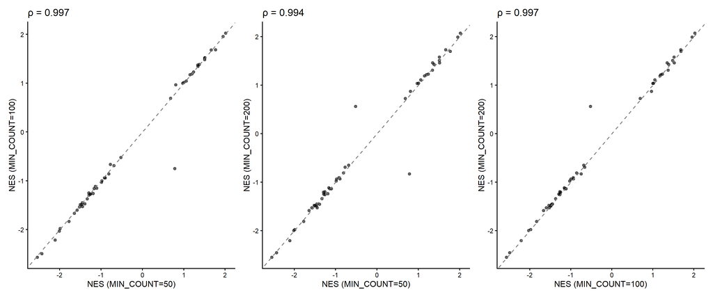

```
## Saved: sweep_hallmark_NES_concordance.(png|pdf)  [12x5 in]
```

## 2.4 Save sweep + pick working threshold

```
##
## >>> Using MIN_COUNT = 50 for §3 onward.
```

# 3. voom diagnostics + sample weights

## 3.1 Standard voom mean-variance

`voom(..., plot = TRUE)` draws its own “Mean-variance trend” title; the single-panel mean-variance figure fits comfortably at 6×5 in.

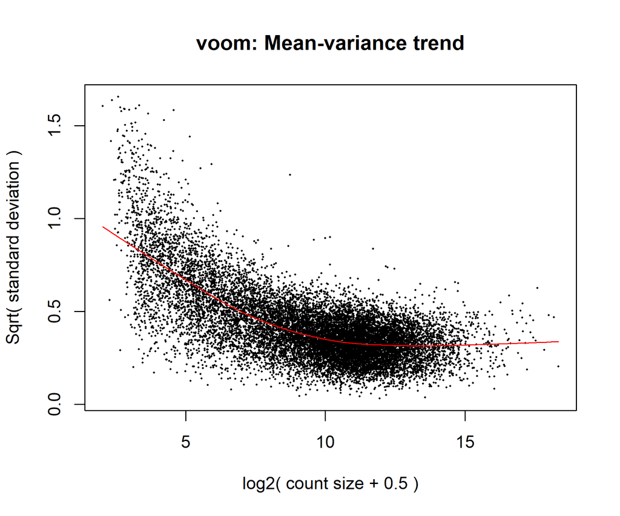

## 3.2 voomWithQualityWeights (sample weights)

`voomWithQualityWeights(..., plot = TRUE)` draws a **two-panel** layout (mean-variance on the left, per-sample weights on the right) — needs a wider canvas than the single-panel §3.1 to keep both panels readable.

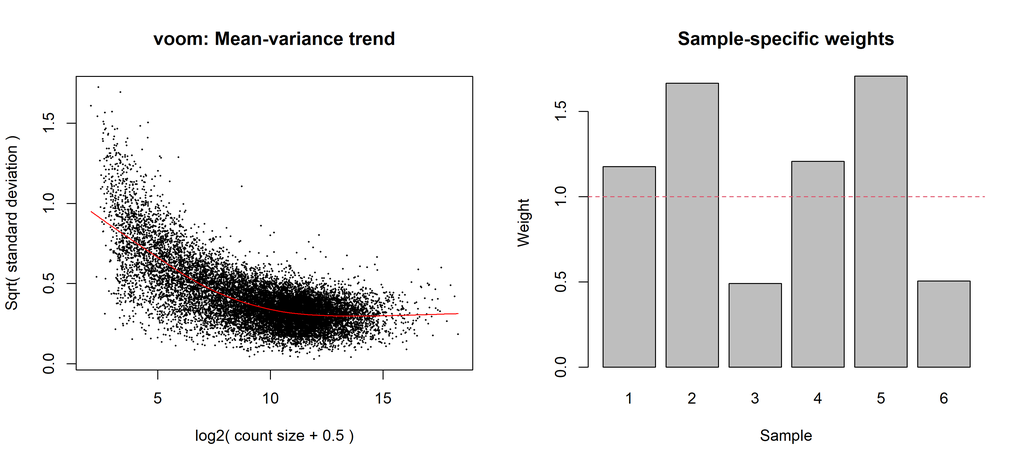

## 3.3 Per-sample weights table

Per-sample voomQW sample weights

| sample | treatment | passage | lib.size | norm.factors | sample_weight | lib.size_M |
| --- | --- | --- | --- | --- | --- | --- |
| LNCaP-LOY-P12 | LOY | 12 | 53847970 | 1.0216352 | 1.176 | 53.8 |
| LNCaP-LOY-P13 | LOY | 13 | 46167485 | 1.0315967 | 1.665 | 46.2 |
| LNCaP-LOY-P14 | LOY | 14 | 45578144 | 0.9763398 | 0.491 | 45.6 |
| LNCaP-sgCTRL-P12 | CTRL | 12 | 55525192 | 1.0170487 | 1.207 | 55.5 |
| LNCaP-sgCTRL-P13 | CTRL | 13 | 53316568 | 1.0304869 | 1.706 | 53.3 |
| LNCaP-sgCTRL-P14 | CTRL | 14 | 36121652 | 0.9272758 | 0.506 | 36.1 |

## 3.4 Weight visualization

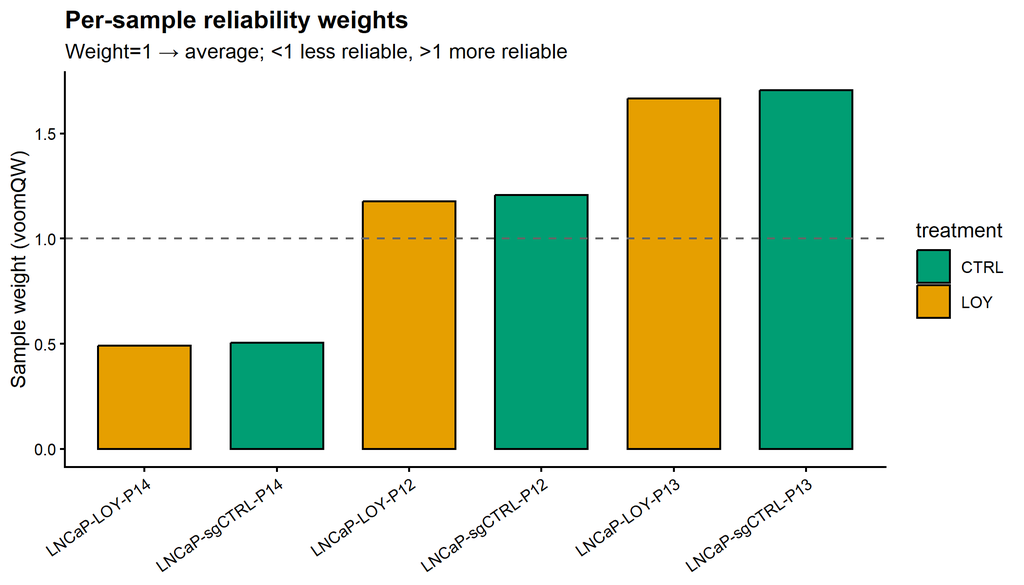

```
## Saved: voomQW_sample_weights.(png|pdf)  [7x4 in]
```

## 3.5 voom vs voomQW concordance

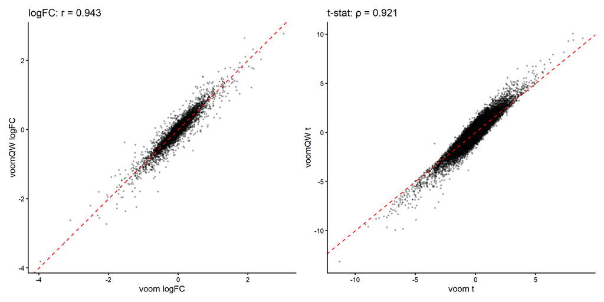

```
## Saved: voom_vs_voomQW_concordance.(png|pdf)  [10x5 in]
```

# 4. Effect-size-aware DE with `treat()`

`treat()` tests `|logFC| > LFC_THR` instead of `≠ 0`. This is what the post-hoc filter in the canonical report tried to approximate, but treat does it inside the test — giving correct p-values for the effect-size question. Run side-by-side on both designs (paired / unpaired) so the choice of baseline is itself a robustness axis.

treat() — sig DEG counts by design (LNCaP)

| design | n_FDR_0.05 | n_FDR_0.05_up | n_FDR_0.05_down |
| --- | --- | --- | --- |
| paired | 1 | 0 | 1 |
| unpaired | 0 | 0 | 0 |

## 4.0 Y-region volcano (pre-strip)

A LOY-vs-sgCTRL paired DE run on a **Y-retaining and PAR-retaining** working set (mirror of `dge0_full` above but skips the `excluded_gene_ids` strip). Every chrY (MSY-Yp / MSY-Yq) and chrX-PAR (PAR1 / PAR2) gene that passes filterByExpr appears with a real `logFC` + `FDR` value — so the volcano shows what the LOY perturbation does to the Y-linked + PAR expression landscape before §4.1+ strips those genes for downstream pathway analysis.

This view was previously impossible because the upstream STAR pipeline dropped PAR multi-mappers (all PAR genes had ~0 reads). Now that `STAR_v2_PARfix` counts are loaded (see §1.2), PAR genes have real values.

```
## Y-retaining paired DE: 14667 genes tested
```

```
##   Y-region genes: 24  [PAR1=14, PAR2=2, MSY-Yp=3, MSY-Yq=5]
```

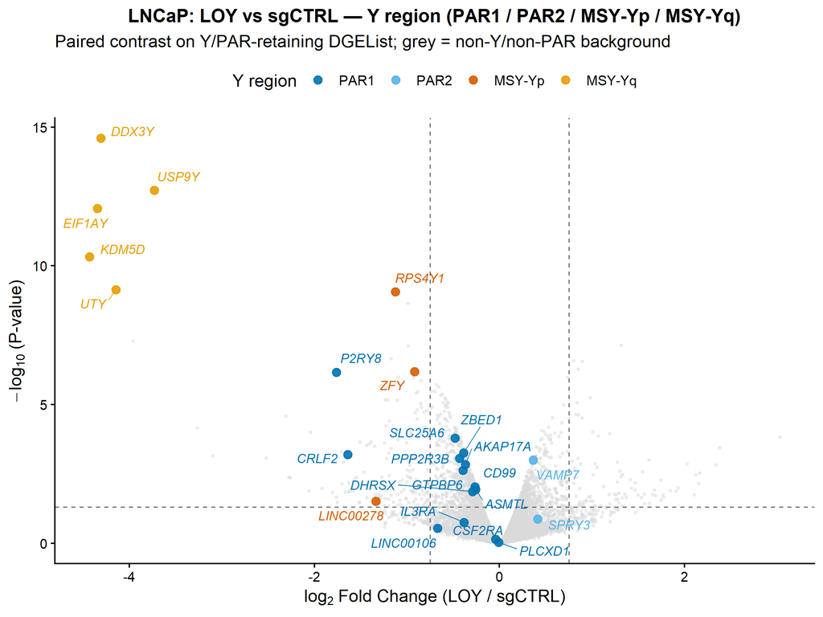

```
## Saved: volcano_LOY_v_sgCTRL_yregion.(png|pdf)  [8x6 in]
```

## 4.1 treat volcano (by design)

### Paired

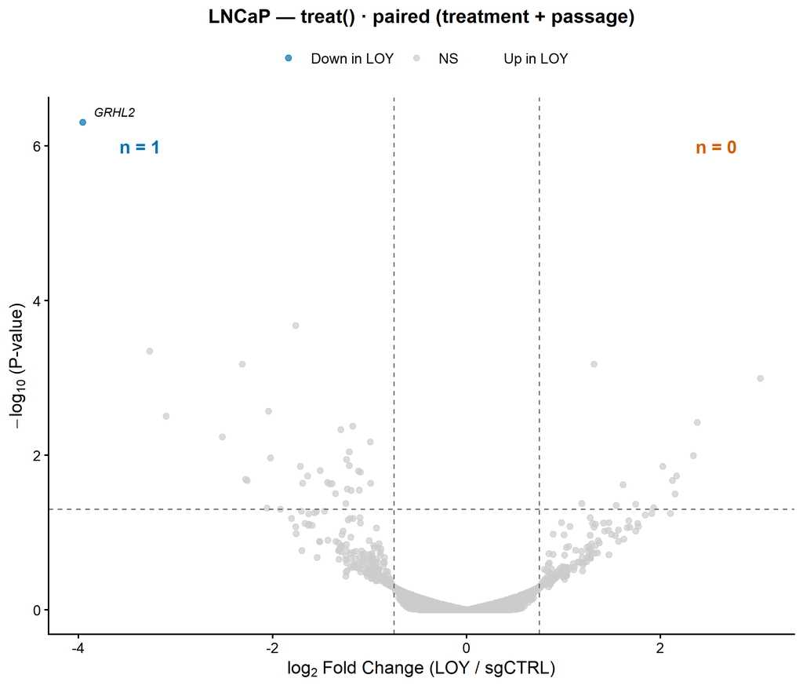

```
## Saved: volcano_treat_paired.(png|pdf)  [7x6 in]
```

### Unpaired

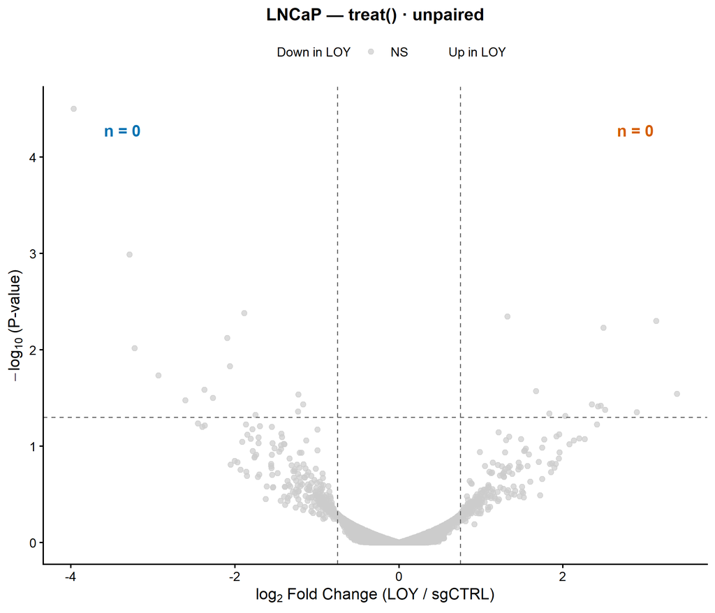

```
## Saved: volcano_treat_unpaired.(png|pdf)  [7x6 in]
```

## 4.2 treat-significant vs post-hoc filtered overlap (paired)

The standard comparison: does `treat()` (effect-size-aware test) recover the same DEGs as the canonical voom + post-hoc `|lfc|>0.75` filter on the paired design? Run on paired only — the design choice is independent of the treat-vs-post-hoc comparison.

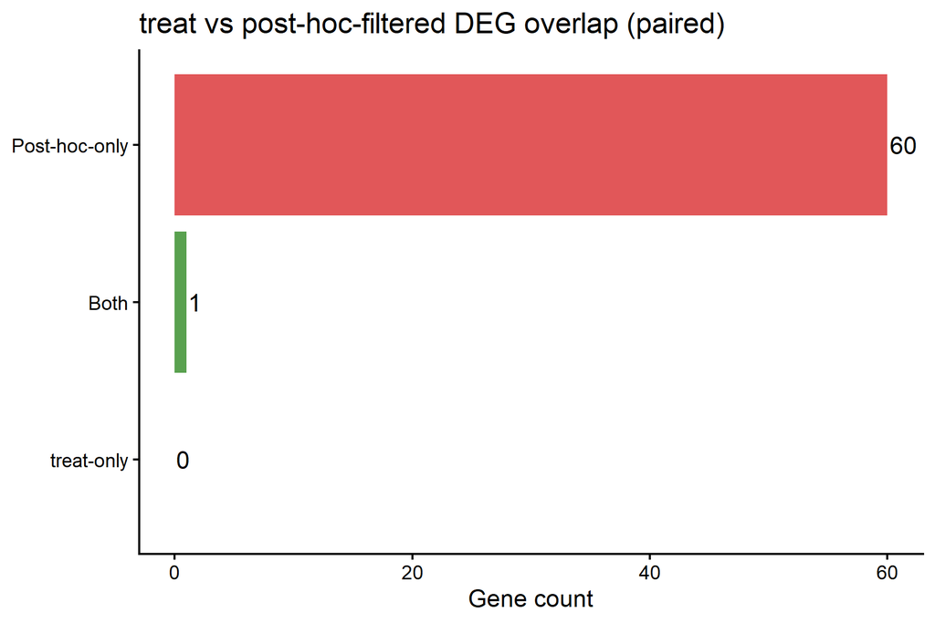

```
## Saved: treat_vs_posthoc_overlap_paired.(png|pdf)  [6x4 in]
```

## 4.3 Cross-design DEG overlap (treat)

How much of the canonical paired-treat DEG set is recovered by the unpaired design? Strong overlap means the LOY effect is reproducible across baseline choice.

treat() DEG overlap with paired (anchor) — per design

| design | this_only | both_vs_paired | paired_only_vs_this |
| --- | --- | --- | --- |
| paired | 0 | 1 | 0 |
| unpaired | 0 | 0 | 1 |

# 5. edgeR quasi-likelihood cross-check

Second statistical framework on each of the two designs — voom/limma’s gaussian-on-logCPM vs edgeR’s negative-binomial-with-QL. Convergent signal across both frameworks for the same design is the strongest evidence that the LOY effect is real.

edgeR-QL sig DEG counts by design (LNCaP)

| design | n_FDR_0.05 | n_FDR_0.05_&_lfc>thr |
| --- | --- | --- |
| paired | 182 | 65 |
| unpaired | 1 | 1 |

## 5.1 BCV plot (by design)

### Paired

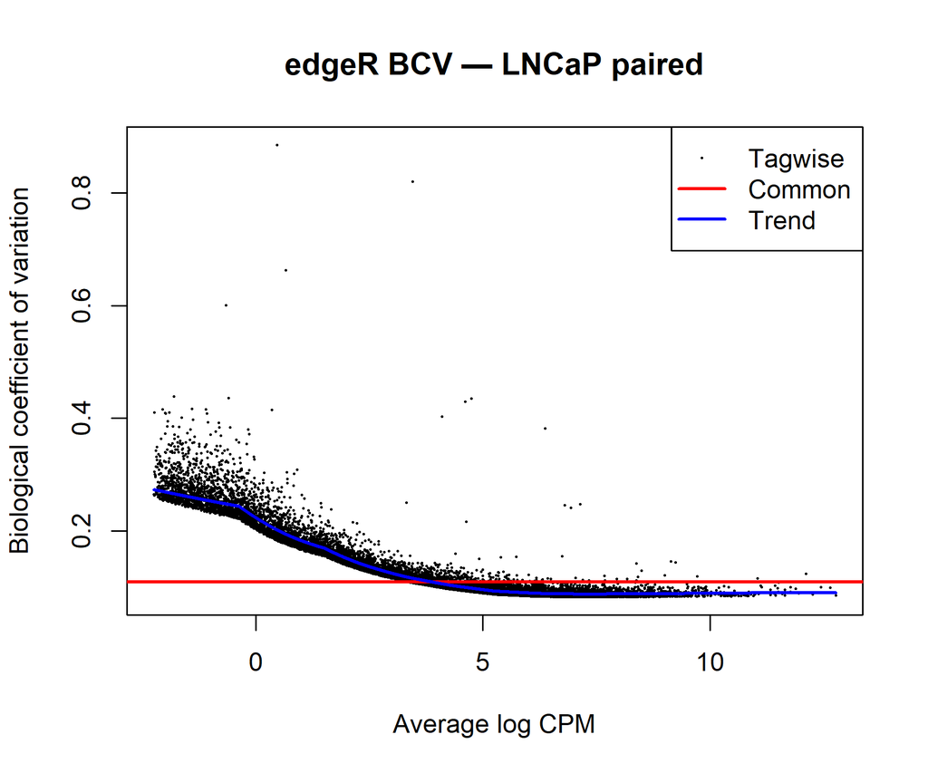

### Unpaired

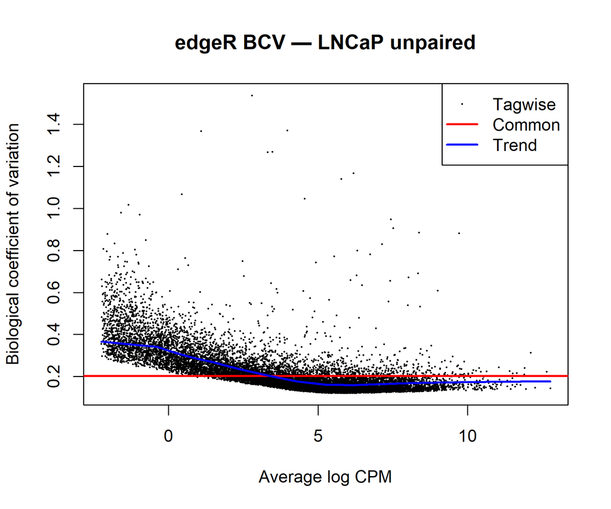

## 5.2 QL t-stat concordance with voom (by design)

### Paired

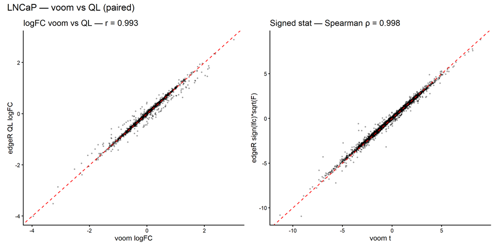

```
## Saved: voom_vs_QL_concordance_paired.(png|pdf)  [10x5 in]
```

### Unpaired

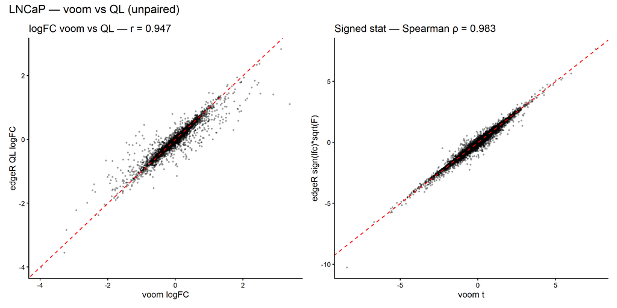

```
## Saved: voom_vs_QL_concordance_unpaired.(png|pdf)  [10x5 in]
```

## 5.3 Top-200 DEG overlap (per design)

Top-200 voom ∩ top-200 QL per design (n out of 200)

| design | intersect | pct |
| --- | --- | --- |
| paired | 187 | 93.5% |
| unpaired | 182 | 91.0% |

# 6. `camera` gene-set testing

`camera` is a competitive gene-set test that accounts for inter-gene correlation — a complement to the (rank-based, correlation-naive) fgsea results in the canonical report’s §5.

```
## Loading MSigDB collections for camera...
```

camera FDR<0.05 hits by design × collection (LNCaP)

| design | hallmark_sig | cgp_sig | reactome_sig |
| --- | --- | --- | --- |
| paired | 10 | 232 | 31 |
| unpaired | 6 | 113 | 26 |

## 6.1 camera vs fgsea: Hallmark side-by-side (by design)

### Paired

Top-25 Hallmark sets: camera vs fgsea (paired)

| pathway | camera_Dir | camera_FDR | camera_PValue | NES | padj_fgsea | agree |
| --- | --- | --- | --- | --- | --- | --- |
| HALLMARK_INTERFERON_ALPHA_RESPONSE | Down | 0.0000 | 0.0000 | -2.5413 | 0.0000 | agree Down |
| HALLMARK_INTERFERON_GAMMA_RESPONSE | Down | 0.0000 | 0.0000 | -2.4287 | 0.0000 | agree Down |
| HALLMARK_INFLAMMATORY_RESPONSE | Down | 0.0008 | 0.0001 | -2.1096 | 0.0000 | agree Down |
| HALLMARK_TNFA_SIGNALING_VIA_NFKB | Down | 0.0013 | 0.0001 | -2.0101 | 0.0000 | agree Down |
| HALLMARK_G2M_CHECKPOINT | Up | 0.0019 | 0.0002 | 1.9486 | 0.0000 | agree Up |
| HALLMARK_MITOTIC_SPINDLE | Up | 0.0034 | 0.0004 | 2.0111 | 0.0000 | agree Up |
| HALLMARK_E2F_TARGETS | Up | 0.0241 | 0.0034 | 1.6606 | 0.0002 | agree Up |
| HALLMARK_ALLOGRAFT_REJECTION | Down | 0.0314 | 0.0050 | -1.7751 | 0.0011 | agree Down |
| HALLMARK_IL6_JAK_STAT3_SIGNALING | Down | 0.0325 | 0.0058 | -1.9901 | 0.0003 | agree Down |
| HALLMARK_HEDGEHOG_SIGNALING | Up | 0.0338 | 0.0068 | 1.7683 | 0.0115 | agree Up |
| HALLMARK_FATTY_ACID_METABOLISM | Up | 0.0719 | 0.0158 | 1.5111 | 0.0131 | agree Up |
| HALLMARK_OXIDATIVE_PHOSPHORYLATION | Up | 0.0802 | 0.0193 | 1.5066 | 0.0054 | agree Up |
| HALLMARK_APOPTOSIS | Down | 0.1282 | 0.0339 | -1.5789 | 0.0092 | agree Down |
| HALLMARK_P53_PATHWAY | Down | 0.1282 | 0.0359 | -1.5214 | 0.0115 | agree Down |
| HALLMARK_ANGIOGENESIS | Down | 0.1342 | 0.0425 | -1.4994 | 0.1115 | agree Down |
| HALLMARK_REACTIVE_OXYGEN_SPECIES_PATHWAY | Up | 0.1342 | 0.0429 | 1.5050 | 0.0428 | agree Up |
| HALLMARK_MTORC1_SIGNALING | Up | 0.1528 | 0.0520 | 1.3758 | 0.0257 | agree Up |
| HALLMARK_XENOBIOTIC_METABOLISM | Up | 0.1930 | 0.0695 | 1.3364 | 0.0443 | agree Up |
| HALLMARK_SPERMATOGENESIS | Up | 0.2196 | 0.0851 | 1.3431 | 0.0900 | agree Up |
| HALLMARK_PROTEIN_SECRETION | Up | 0.2196 | 0.0879 | 1.2378 | 0.1636 | agree Up |
| HALLMARK_COAGULATION | Down | 0.2757 | 0.1158 | -1.4493 | 0.0601 | agree Down |
| HALLMARK_APICAL_JUNCTION | Down | 0.3013 | 0.1326 | -1.6458 | 0.0039 | agree Down |
| HALLMARK_WNT_BETA_CATENIN_SIGNALING | Down | 0.3192 | 0.1502 | -1.2587 | 0.2395 | agree Down |
| HALLMARK_COMPLEMENT | Down | 0.3192 | 0.1558 | -1.3909 | 0.0265 | agree Down |
| HALLMARK_ADIPOGENESIS | Up | 0.3192 | 0.1596 | 1.1485 | 0.2395 | agree Up |

```
## Direction agreement: 42 / 50
```

### Unpaired

Top-25 Hallmark sets: camera vs fgsea (unpaired)

| pathway | camera_Dir | camera_FDR | camera_PValue | NES | padj_fgsea | agree |
| --- | --- | --- | --- | --- | --- | --- |
| HALLMARK_INTERFERON_ALPHA_RESPONSE | Down | 0.0000 | 0.0000 | -2.3185 | 0.0000 | agree Down |
| HALLMARK_INTERFERON_GAMMA_RESPONSE | Down | 0.0000 | 0.0000 | -2.2900 | 0.0000 | agree Down |
| HALLMARK_INFLAMMATORY_RESPONSE | Down | 0.0172 | 0.0010 | -1.8855 | 0.0001 | agree Down |
| HALLMARK_MITOTIC_SPINDLE | Up | 0.0183 | 0.0015 | 1.8890 | 0.0000 | agree Up |
| HALLMARK_G2M_CHECKPOINT | Up | 0.0230 | 0.0023 | 1.7243 | 0.0002 | agree Up |
| HALLMARK_HEDGEHOG_SIGNALING | Up | 0.0419 | 0.0050 | 1.6903 | 0.0542 | agree Up |
| HALLMARK_TNFA_SIGNALING_VIA_NFKB | Down | 0.0581 | 0.0087 | -1.7313 | 0.0003 | agree Down |
| HALLMARK_ALLOGRAFT_REJECTION | Down | 0.0581 | 0.0093 | -1.8158 | 0.0007 | agree Down |
| HALLMARK_IL6_JAK_STAT3_SIGNALING | Down | 0.0587 | 0.0106 | -1.8922 | 0.0017 | agree Down |
| HALLMARK_OXIDATIVE_PHOSPHORYLATION | Up | 0.1279 | 0.0256 | 1.4814 | 0.0189 | agree Up |
| HALLMARK_FATTY_ACID_METABOLISM | Up | 0.1438 | 0.0316 | 1.3924 | 0.0542 | agree Up |
| HALLMARK_E2F_TARGETS | Up | 0.1573 | 0.0377 | 1.3001 | 0.0872 | agree Up |
| HALLMARK_ANGIOGENESIS | Down | 0.2166 | 0.0563 | -1.4342 | 0.2080 | agree Down |
| HALLMARK_REACTIVE_OXYGEN_SPECIES_PATHWAY | Up | 0.2225 | 0.0636 | 1.3237 | 0.2291 | agree Up |
| HALLMARK_XENOBIOTIC_METABOLISM | Up | 0.2225 | 0.0667 | 1.4001 | 0.0590 | agree Up |
| HALLMARK_APICAL_JUNCTION | Down | 0.2307 | 0.0738 | -1.6150 | 0.0061 | agree Down |
| HALLMARK_P53_PATHWAY | Down | 0.2594 | 0.0882 | -1.3351 | 0.1249 | agree Down |
| HALLMARK_APOPTOSIS | Down | 0.2833 | 0.1020 | -1.3323 | 0.1249 | agree Down |
| HALLMARK_MTORC1_SIGNALING | Up | 0.3416 | 0.1298 | 1.1228 | 0.3534 | agree Up |
| HALLMARK_SPERMATOGENESIS | Up | 0.3489 | 0.1456 | 1.2203 | 0.2758 | agree Up |
| HALLMARK_PROTEIN_SECRETION | Up | 0.3489 | 0.1466 | 1.0845 | 0.4728 | agree Up |
| HALLMARK_ADIPOGENESIS | Up | 0.5098 | 0.2243 | 1.0340 | 0.5417 | agree Up |
| HALLMARK_WNT_BETA_CATENIN_SIGNALING | Down | 0.5145 | 0.2463 | -1.1858 | 0.3768 | agree Down |
| HALLMARK_TGF_BETA_SIGNALING | Down | 0.5145 | 0.2470 | -1.2152 | 0.3233 | agree Down |
| HALLMARK_ANDROGEN_RESPONSE | Up | 0.5601 | 0.2903 | 1.0105 | 0.5957 | agree Up |

```
## Direction agreement: 46 / 50
```

## 6.2 camera Hallmark dotplot (by design)

### Paired

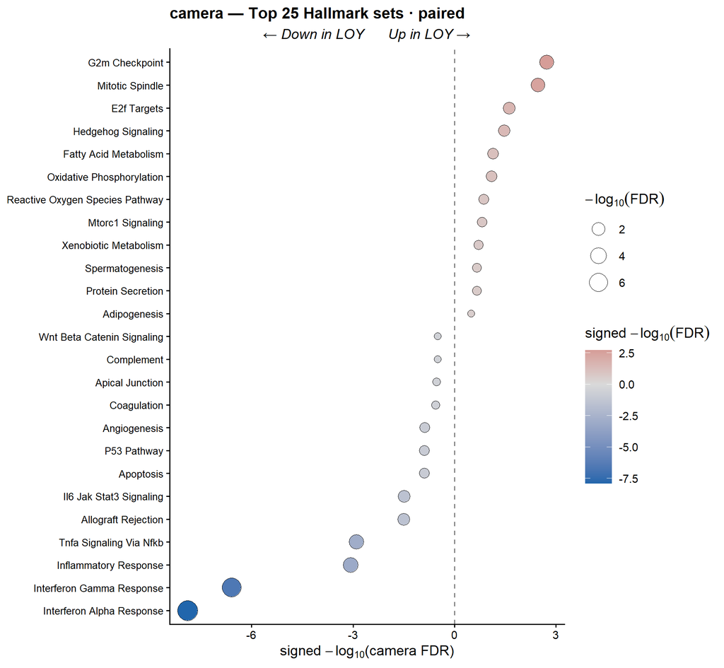

```
## Saved: camera_hallmark_dotplot_paired.(png|pdf)  [6.5x6 in]
```

### Unpaired

[figure not shown]

```
## Saved: camera_hallmark_dotplot_unpaired.(png|pdf)  [6.5x6 in]
```

# 7. Sex-chromosome homologs / Y-linked paralog deep-dive

```
## Paralog genes detected: 16 / 20
```

```
## Missing (filtered out or unannotated):  TMSB4Y, PRKY, NLGN4Y, NLGN4X
```

## 7.1 Per-pair boxplots

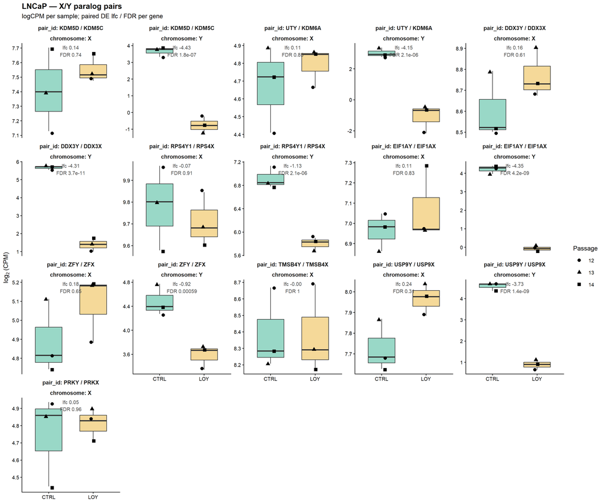

```
## Saved: paralog_boxplots.(png|pdf)  [12x10 in]
```

## 7.2 Y-gene logFC vs paralogous X-gene logFC

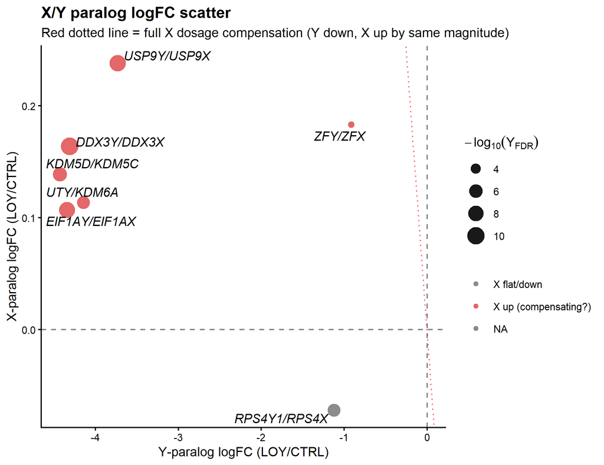

```
## Saved: paralog_logFC_scatter.(png|pdf)  [6.5x5 in]
```

## 7.3 Dosage-compensation index

X/Y paralog dosage-compensation summary

[output not shown]

## 7.4 Paralog heatmap

Z-scaled logCPM heatmap of the X/Y paralog pairs on the paired LOY-vs-sgCTRL working set. (The HT1080/A549 extended notebooks include a “with PARENTAL” tab here as an untreated baseline check for sgRNA artifacts; LNCaP has no PARENTAL arm so only the LOY+sgCTRL view is shown.)

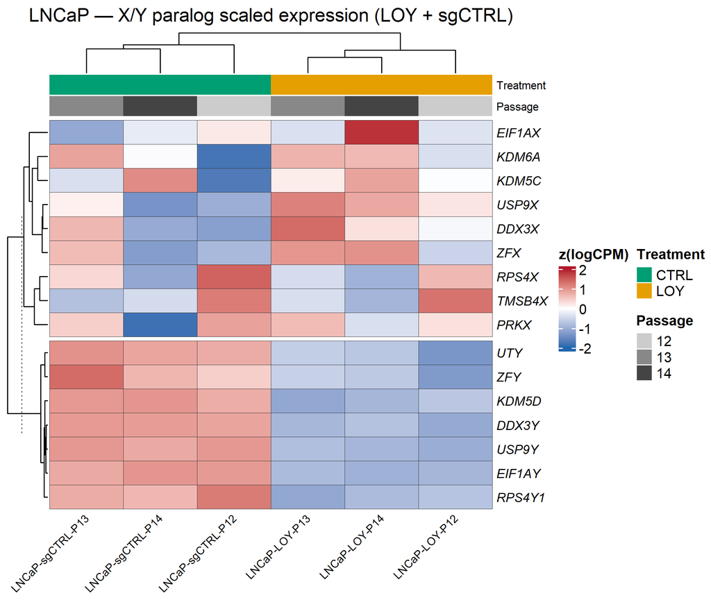

```
## Saved: paralog_heatmap.(png|pdf)
```

# 8. Sample-level pathway scoring

Goal: instead of contrast-level enrichment, score each Hallmark / PROGENy / custom signature per sample, then test the score with the paired model.

## 8.1 GSVA / ssGSEA on Hallmark

```
## ssGSEA: 50 Hallmark sets x 6 samples
```

## 8.2 PROGENy pathway activity

```
## PROGENy: 14 pathways x 6 samples
```

## 8.3 decoupleR-PROGENy (cross-method check)

```
## decoupleR-PROGENy: 14 pathways x 6 samples
```

## 8.4 PROGENy vs decoupleR-PROGENy concordance

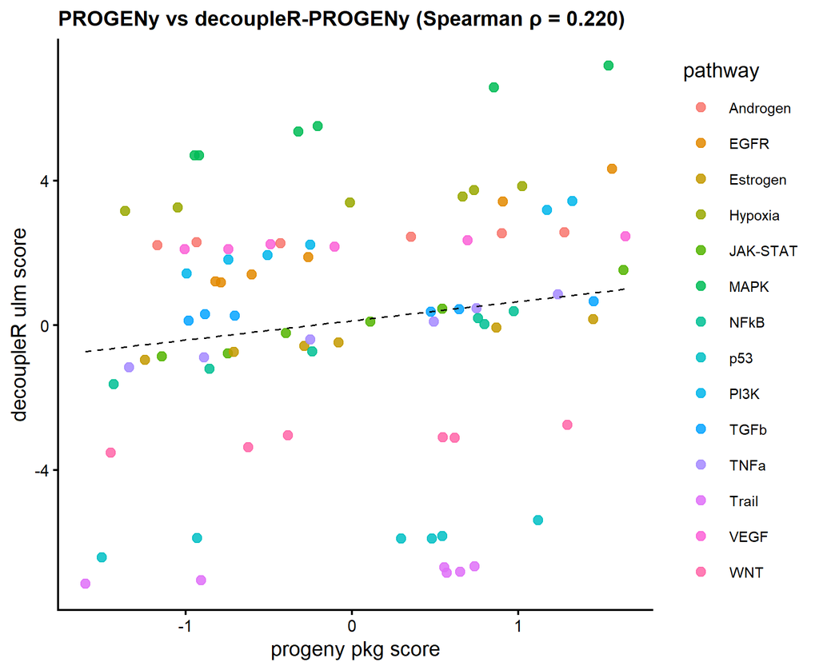

```
## Saved: progeny_vs_decoupleR_concord.(png|pdf)  [5.5x4.5 in]
```

## 8.5 Custom signatures (LOY / PRC2-bivalent / chrY)

```
## Custom signature sizes (after gene-matrix filter):
```

```
## LOY_down_top50  PRC2_bivalent    chrY_coding
##             45           1238              7
```

## 8.6 LM test on each score (paired vs unpaired)

Per-pathway score shift tested against treatment. Paired (`~ treatment + passage`) is the canonical analysis; unpaired (`~ treatment`) is the robustness comparison — agreement between the two means the passage block isn’t carrying the signal.

Note: a “pooled” LM here would require re-scoring GSVA/PROGENy on the full 9-sample DGEList (CTRL + LOY + PARENTAL). Sample-level scoring above is on the 6-sample CTRL+LOY working set, so paired/unpaired is the natural pair of tests at the score level. The DE-level pooled design is tested in §4/§5.

### Paired

```
## Top 15 sample-level pathway score shifts (paired):
```

| pathway | method | beta_LOY | SE | p_value | FDR |
| --- | --- | --- | --- | --- | --- |
| chrY_coding | ssGSEA_custom | -0.949 | 0.026 | 0.0008 | 0.0023 |
| HALLMARK_MITOTIC_SPINDLE | ssGSEA_hallmark | 0.013 | 0.001 | 0.0033 | 0.1655 |
| LOY_down_top50 | ssGSEA_custom | -0.443 | 0.039 | 0.0077 | 0.0115 |
| PI3K | decoupleR_PROGENy | 0.386 | 0.078 | 0.0384 | 0.3907 |
| HALLMARK_ANGIOGENESIS | ssGSEA_hallmark | -0.011 | 0.002 | 0.0392 | 0.5933 |
| TNFa | decoupleR_PROGENy | -0.717 | 0.177 | 0.0558 | 0.3907 |
| HALLMARK_PEROXISOME | ssGSEA_hallmark | 0.007 | 0.002 | 0.0585 | 0.5933 |
| HALLMARK_HEME_METABOLISM | ssGSEA_hallmark | 0.005 | 0.001 | 0.0600 | 0.5933 |
| HALLMARK_COAGULATION | ssGSEA_hallmark | -0.017 | 0.004 | 0.0625 | 0.5933 |
| TNFa | PROGENy | -0.988 | 0.263 | 0.0639 | 0.2753 |
| HALLMARK_MTORC1_SIGNALING | ssGSEA_hallmark | 0.007 | 0.002 | 0.0721 | 0.5933 |
| p53 | PROGENy | -0.444 | 0.130 | 0.0763 | 0.2753 |
| VEGF | PROGENy | -1.491 | 0.444 | 0.0784 | 0.2753 |
| PI3K | PROGENy | 0.378 | 0.113 | 0.0787 | 0.2753 |
| HALLMARK_FATTY_ACID_METABOLISM | ssGSEA_hallmark | 0.008 | 0.003 | 0.0841 | 0.5933 |

### Unpaired

```
## Top 15 sample-level pathway score shifts (unpaired):
```

| pathway | method | beta_LOY | SE | p_value | FDR |
| --- | --- | --- | --- | --- | --- |
| chrY_coding | ssGSEA_custom | -0.949 | 0.023 | 0.0000 | 0.0000 |
| LOY_down_top50 | ssGSEA_custom | -0.443 | 0.089 | 0.0075 | 0.0113 |
| HALLMARK_FATTY_ACID_METABOLISM | ssGSEA_hallmark | 0.008 | 0.003 | 0.0304 | 0.9323 |
| VEGF | PROGENy | -1.491 | 0.527 | 0.0473 | 0.6627 |
| HALLMARK_ANGIOGENESIS | ssGSEA_hallmark | -0.011 | 0.004 | 0.0570 | 0.9323 |
| HALLMARK_PEROXISOME | ssGSEA_hallmark | 0.007 | 0.003 | 0.0757 | 0.9323 |
| HALLMARK_MITOTIC_SPINDLE | ssGSEA_hallmark | 0.013 | 0.006 | 0.1131 | 0.9323 |
| HALLMARK_COAGULATION | ssGSEA_hallmark | -0.017 | 0.009 | 0.1379 | 0.9323 |
| VEGF | decoupleR_PROGENy | -0.174 | 0.098 | 0.1515 | 0.8780 |
| HALLMARK_APOPTOSIS | ssGSEA_hallmark | -0.007 | 0.004 | 0.1642 | 0.9323 |
| HALLMARK_MTORC1_SIGNALING | ssGSEA_hallmark | 0.007 | 0.005 | 0.1991 | 0.9323 |
| HALLMARK_INFLAMMATORY_RESPONSE | ssGSEA_hallmark | -0.014 | 0.010 | 0.2192 | 0.9323 |
| HALLMARK_INTERFERON_GAMMA_RESPONSE | ssGSEA_hallmark | -0.024 | 0.017 | 0.2259 | 0.9323 |
| HALLMARK_KRAS_SIGNALING_UP | ssGSEA_hallmark | -0.006 | 0.004 | 0.2269 | 0.9323 |
| TGFb | decoupleR_PROGENy | 0.186 | 0.134 | 0.2388 | 0.8780 |

## 8.7 Heatmap of Hallmark scores

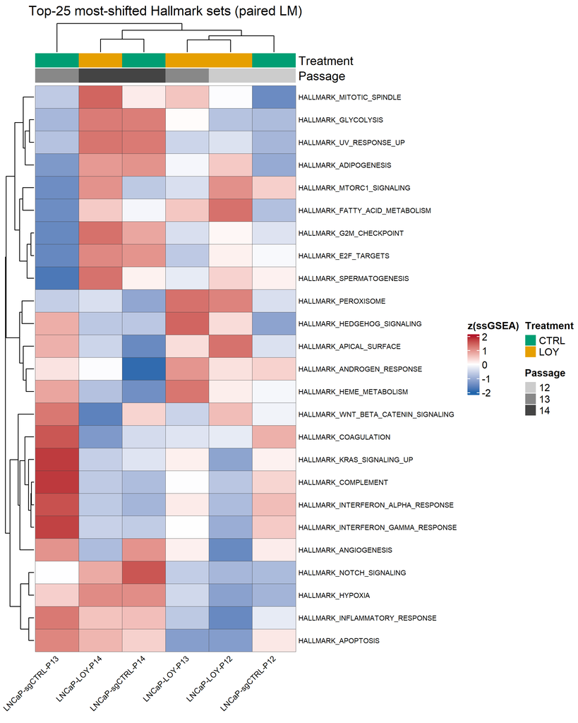

## 8.8 Top-6 score boxplots

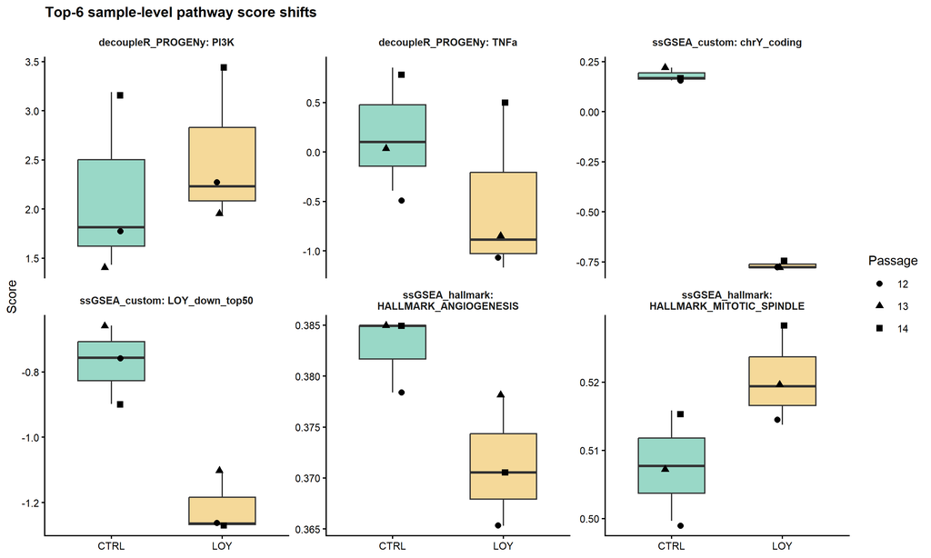

```
## Saved: top6_pathway_score_boxplots.(png|pdf)  [10x6 in]
```

# 9. lpWGS copy-number integration

**Data**: LNCaP lpWGS, single timepoint, T2T-CHM13v2.0. Pre-segmented by QDNAseq in `projects/WGS/code/coverage_report_LNCaP_QDNAseq.Rmd`, exported as `LNCaP_QDNAseq_cn.rds` + `LNCaP_QDNAseq_cn_df.rds`. The LNCaP lpWGS panel contains several arms (sgCTRL, LOY-2X, DMSO-LOY-1X, plus drug-treated arms: Pano-30/70, KU, KU+Pano-30/70). For the RNA-seq LOY-vs-sgCTRL CN backdrop here we use the **`sgCTRL`** and **`LOY-2X`** arms (LOY-2X is the primary LOY arm referenced in the QDNAseq report’s chrY zoom panel; the 1× DMSO-LOY arm and drug arms are excluded). With only one sample per arm the CN map is treated as a **population backdrop** for the RNA-seq contrast, not per-replicate matched.

## 9.1 Load CN object

```
## Loaded CN: 31185 bins x 8 samples (T2T-CHM13)
```

```
## [1] sgCTRL      LOY-2X      DMSO-LOY-1X Pano-30     Pano-70     KU
## [7] KU+Pano-30  KU+Pano-70
## 8 Levels: sgCTRL LOY-2X DMSO-LOY-1X Pano-30 Pano-70 KU ... KU+Pano-70
```

## 9.2 Build T2T-CHM13 gene coordinate index

```
## Loading T2T-CHM13v2.0 GTF (may take ~30s)...
```

```
## T2T gene index: 57711 genes across chroms chr1,chr2,chr3,chr4,chr5,chr6,chr7,chr8,chr9,chr10,chr11,chr12,chr13,chr14,chr15,chr16,chr17,chr18,chr19,chr20,chr21,chr22,chrX,chrY
```

## 9.3 Overlap RNA genes onto QDNAseq bins

```
## Genes with CN mapping: 13719 / 14657 in DE
```

## 9.4 Annotate DE table with CN

```
## DEGs (FDR<0.05) flagged as CN-driven:  46  /  184
```

## 9.5 DEG volcano colored by CN state — cutoff sweep

The classifier compares each gene’s lpWGS `cn_delta = log2(LOY/sgCTRL)` at its bin to a Gain/Loss cutoff. The sensible range is 0.3–0.5 (0.3 ≈ 1.23× signal shift, 0.5 ≈ 1.41× shift). Three tabs at 0.3 / 0.4 / 0.5; tighter cutoffs keep only the most confident CN shifts. The 3-across composite is also saved to disk as `volcano_LOY_v_sgCTRL_cn_cutoff_sweep.(png|pdf)`.

```
## Saved: volcano_LOY_v_sgCTRL_cn_cutoff_sweep.(png|pdf)  [18x6 in]
```

### |cn_delta| > 0.3

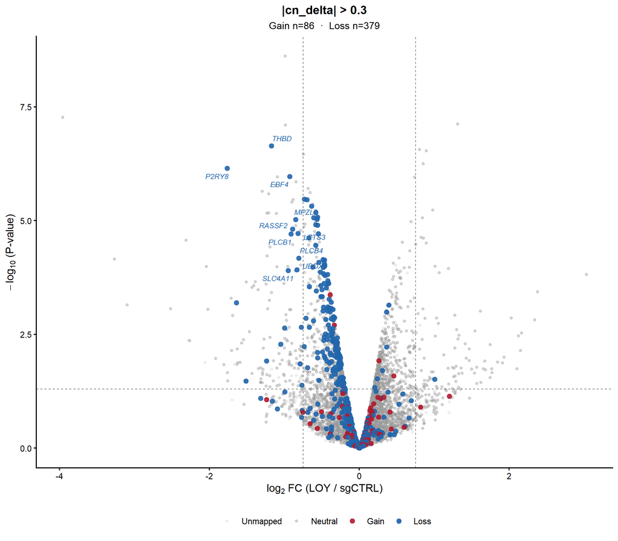

### |cn_delta| > 0.4

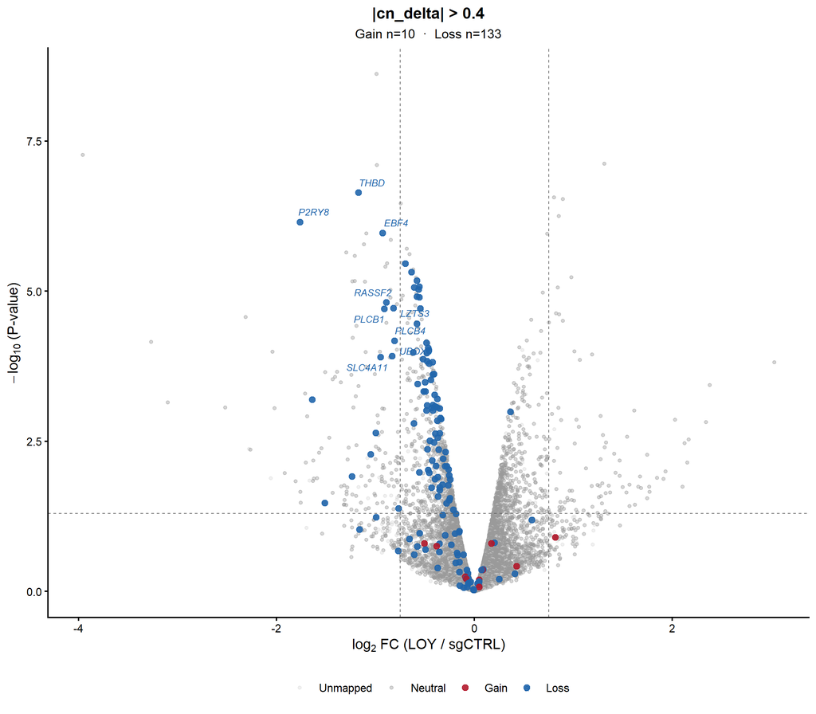

### |cn_delta| > 0.5

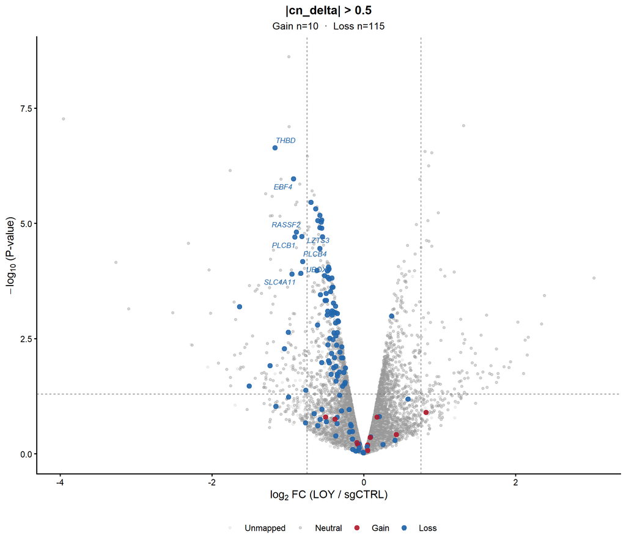

### Gene counts by cutoff

Gene counts by cn_delta cutoff (Gain_among_sig / Loss_among_sig restricted to FDR<0.05 & |logFC|>0.75)

| cutoff | Gain | Loss | Neutral | Unmapped | Gain_among_sig | Loss_among_sig |
| --- | --- | --- | --- | --- | --- | --- |
| 0.3 | 86 | 379 | 13256 | 938 | 0 | 10 |
| 0.4 | 10 | 133 | 13578 | 938 | 0 | 9 |
| 0.5 | 10 | 115 | 13596 | 938 | 0 | 8 |

## 9.6 Chromosome-arm mean shifts

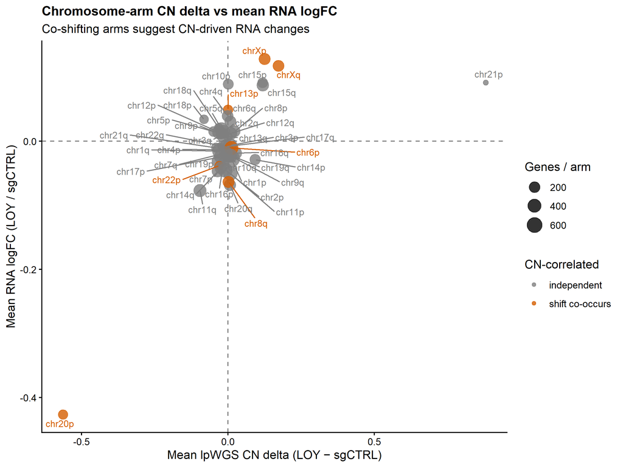

```
## Saved: chromosome_arm_CN_vs_RNA.(png|pdf)  [8x6 in]
```

## 9.7 Per-gene CN delta vs logFC scatter

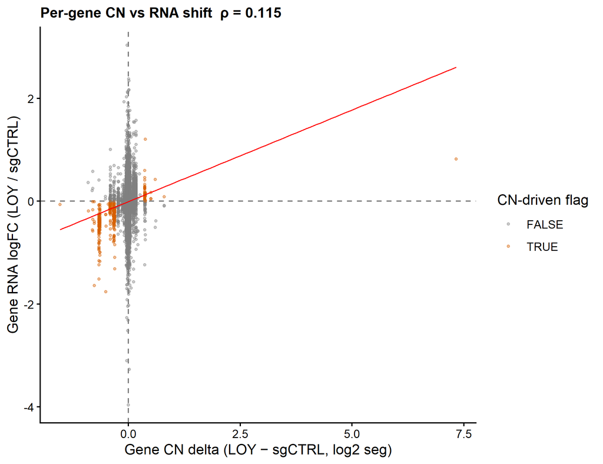

```
## Saved: per_gene_CN_vs_logFC.(png|pdf)  [6.5x5 in]
```

## 9.8 Y-loss confirmation (RNA + lpWGS)

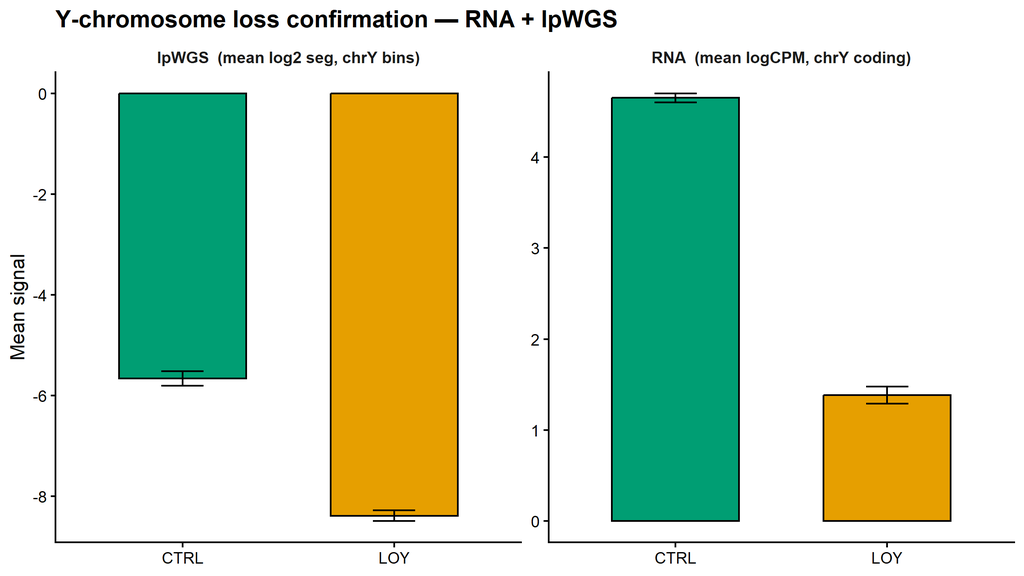

```
## Saved: y_loss_confirmation_RNA_lpWGS.(png|pdf)  [8x4.5 in]
```

## 9.9 CN-flagged DEG sensitivity rerun (by design)

Re-run Hallmark fgsea and decoupleR TF activity with `cn_driven_flag == TRUE` genes removed. Bumps in NES / TF scores that survive this filter are unlikely to be driven by autosomal CN drift. Repeated across both DE designs — the CN flag set itself comes from the paired DE annotation in §9.4, but the upstream rank vectors differ between paired and unpaired, so the sensitivity question is worth asking on each.

```
## Genes flagged CN-driven (anchor: paired DE annotation): 351
```

### Paired

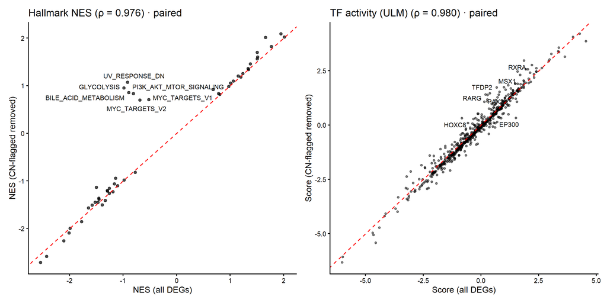

```
## Saved: cn_sensitivity_NES_TF_paired.(png|pdf)  [10x5 in]
```

### Unpaired

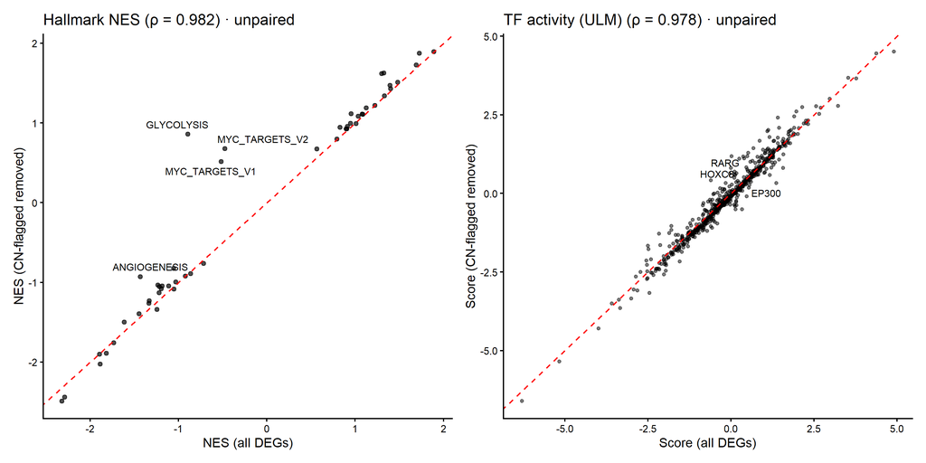

```
## Saved: cn_sensitivity_NES_TF_unpaired.(png|pdf)  [10x5 in]
```

# 10. Robustness summary

Per-gene integration across the four statistical pipelines + CN flag + paralog membership. “Confident DEG” = passes ≥ 3 of {voom, voomQW, treat, edgeR-QL} at FDR<0.05 AND is not flagged CN-driven.

```
## Confident DEGs (≥3/4 frameworks, not CN-driven): 129
```

```
##   up:   43
```

```
##   down: 86
```

```
## Confident + in paralog pair: 0
```

## 10.1 Top confident DEGs

Top-40 confident DEGs

| gene_name | logFC | FDR_voom | FDR_voomQW | FDR_treat | FDR_edgeRQL | n_pass | cn_state_LOY | in_paralog_pair |
| --- | --- | --- | --- | --- | --- | --- | --- | --- |
| TACSTD2 | -0.99 | 0.000 | 0 | 1.000 | 0.000 | 3 | Loss | FALSE |
| GRHL2 | -3.96 | 0.000 | 0 | 0.007 | 0.000 | 4 | Gain | FALSE |
| TAF9 | 1.31 | 0.000 | 0 | 1.000 | 0.000 | 3 | Neutral | FALSE |
| AP1M2 | -0.99 | 0.000 | 0 | 1.000 | 0.000 | 3 | Neutral | FALSE |
| COL4A2 | 0.80 | 0.001 | 0 | 1.000 | 0.000 | 3 | Loss | FALSE |
| F13A1 | 0.89 | 0.001 | 0 | 1.000 | 0.000 | 3 | Neutral | FALSE |
| CLDN7 | -0.75 | 0.001 | 0 | 1.000 | 0.000 | 3 | Neutral | FALSE |
| CREB3L1 | 0.85 | 0.001 | 0 | 1.000 | 0.001 | 3 | Loss | FALSE |
| LCN2 | -1.09 | 0.001 | 0 | 1.000 | 0.004 | 3 | Neutral | FALSE |
| SLC16A2 | 0.73 | 0.001 | 0 | 1.000 | 0.001 | 3 | Loss | FALSE |
| SPOCK2 | -0.85 | 0.001 | 0 | 1.000 | 0.001 | 3 | Neutral | FALSE |
| SCEL | -1.12 | 0.002 | 0 | 1.000 | 0.001 | 3 | Loss | FALSE |
| MDK | -0.68 | 0.002 | 0 | 1.000 | 0.002 | 3 | Loss | FALSE |
| BAHCC1 | -0.66 | 0.002 | 0 | 1.000 | 0.001 | 3 | Neutral | FALSE |
| EPS8L1 | -1.21 | 0.002 | 0 | 1.000 | 0.001 | 3 | Loss | FALSE |
| HOXB9 | -0.88 | 0.002 | 0 | 1.000 | 0.002 | 3 | Neutral | FALSE |
| TMC4 | -0.90 | 0.002 | 0 | 1.000 | 0.003 | 3 | Loss | FALSE |
| EFEMP1 | -0.62 | 0.003 | 0 | 1.000 | 0.002 | 3 | Neutral | FALSE |
| TMEM45A | 0.98 | 0.003 | 0 | 1.000 | 0.002 | 3 | Neutral | FALSE |
| MAL2 | -0.59 | 0.003 | 0 | 1.000 | 0.002 | 3 | Gain | FALSE |
| LTB | -1.21 | 0.003 | 0 | 1.000 | 0.003 | 3 | Neutral | FALSE |
| PKIA | -1.24 | 0.003 | 0 | 1.000 | 0.002 | 3 | Gain | FALSE |
| GOLGA7B | -1.11 | 0.003 | 0 | 1.000 | 0.001 | 3 | Neutral | FALSE |
| ABCG1 | 0.84 | 0.004 | 0 | 1.000 | 0.004 | 3 | Neutral | FALSE |
| NPTX1 | 0.69 | 0.004 | 0 | 1.000 | 0.004 | 3 | Neutral | FALSE |
| SLCO2A1 | -0.59 | 0.004 | 0 | 1.000 | 0.003 | 3 | Neutral | FALSE |
| TMEM30B | -0.73 | 0.004 | 0 | 1.000 | 0.004 | 3 | Neutral | FALSE |
| WFDC2 | -0.85 | 0.004 | 0 | 1.000 | 0.004 | 3 | Loss | FALSE |
| NAPSA | -0.74 | 0.005 | 0 | 1.000 | 0.003 | 3 | Loss | FALSE |
| ATP2C2 | -0.78 | 0.005 | 0 | 1.000 | 0.005 | 3 | Gain | FALSE |
| SNHG19 | -0.60 | 0.006 | 0 | 1.000 | 0.005 | 3 | Neutral | FALSE |
| LAMC3 | -0.63 | 0.007 | 0 | 1.000 | 0.007 | 3 | Neutral | FALSE |
| ANXA8 | 0.82 | 0.007 | 0 | 1.000 | 0.005 | 3 | Neutral | FALSE |
| NPR1 | 0.85 | 0.007 | 0 | 1.000 | 0.008 | 3 | Gain | FALSE |
| CSF1 | -0.54 | 0.007 | 0 | 1.000 | 0.005 | 3 | Loss | FALSE |
| SFTPA1 | -2.31 | 0.007 | 0 | 1.000 | 0.001 | 3 | Neutral | FALSE |
| TNFAIP3 | -0.66 | 0.007 | 0 | 1.000 | 0.004 | 3 | Loss | FALSE |
| CALD1 | -0.53 | 0.008 | 0 | 1.000 | 0.007 | 3 | Neutral | FALSE |
| ABCA1 | 0.57 | 0.008 | 0 | 1.000 | 0.005 | 3 | Neutral | FALSE |
| IRX5 | 0.89 | 0.008 | 0 | 1.000 | 0.006 | 3 | Gain | FALSE |

## 10.2 Framework agreement plot

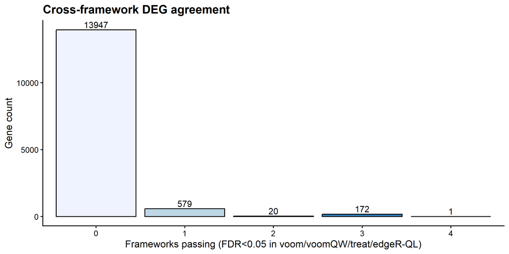

```
## Saved: robust_framework_agreement.(png|pdf)  [8x4 in]
```

## 10.3 Over-representation analysis on confident DEGs

Hypergeometric test (`fgsea::fora`) — does the confident-DEG set (≥3/4 frameworks at FDR<0.05, not CN-driven) overlap pathways more than chance? Up and down are tested separately against the same universe (all tested genes in the working DE).

```
## Universe: 14657 genes
```

```
## Confident up:   43  | down: 86
```

[output not shown]

| pathway | overlap | size | fold_enrichment | padj |
| --- | --- | --- | --- | --- |
| HALLMARK_EPITHELIAL_MESENCHYMAL_TRANSITION | 7 | 155 | 15.39 | 0.0000 |
| HALLMARK_UV_RESPONSE_UP | 3 | 144 | 7.10 | 0.2150 |
| HALLMARK_TNFA_SIGNALING_VIA_NFKB | 3 | 180 | 5.68 | 0.2614 |
| HALLMARK_FATTY_ACID_METABOLISM | 2 | 132 | 5.16 | 0.5823 |
| HALLMARK_MYOGENESIS | 2 | 148 | 4.61 | 0.5823 |
| HALLMARK_HEME_METABOLISM | 2 | 165 | 4.13 | 0.5823 |
| HALLMARK_HEDGEHOG_SIGNALING | 1 | 30 | 11.36 | 0.5823 |
| HALLMARK_ADIPOGENESIS | 2 | 175 | 3.90 | 0.5823 |
| HALLMARK_BILE_ACID_METABOLISM | 1 | 83 | 4.11 | 0.8085 |
| HALLMARK_PEROXISOME | 1 | 88 | 3.87 | 0.8085 |
| HALLMARK_PROTEIN_SECRETION | 1 | 94 | 3.63 | 0.8085 |
| HALLMARK_KRAS_SIGNALING_DN | 1 | 114 | 2.99 | 0.8085 |
| HALLMARK_DNA_REPAIR | 1 | 142 | 2.40 | 0.8085 |
| HALLMARK_INFLAMMATORY_RESPONSE | 1 | 144 | 2.37 | 0.8085 |
| HALLMARK_KRAS_SIGNALING_UP | 1 | 151 | 2.26 | 0.8085 |
| HALLMARK_XENOBIOTIC_METABOLISM | 1 | 153 | 2.23 | 0.8085 |
| HALLMARK_COMPLEMENT | 1 | 161 | 2.12 | 0.8085 |
| HALLMARK_APICAL_JUNCTION | 1 | 165 | 2.07 | 0.8085 |
| HALLMARK_IL2_STAT5_SIGNALING | 1 | 166 | 2.05 | 0.8085 |
| HALLMARK_ESTROGEN_RESPONSE_LATE | 1 | 174 | 1.96 | 0.8085 |
| HALLMARK_ESTROGEN_RESPONSE_EARLY | 1 | 179 | 1.90 | 0.8085 |
| HALLMARK_HYPOXIA | 1 | 179 | 1.90 | 0.8085 |
| HALLMARK_P53_PATHWAY | 1 | 182 | 1.87 | 0.8085 |
| HALLMARK_OXIDATIVE_PHOSPHORYLATION | 1 | 185 | 1.84 | 0.8085 |
| HALLMARK_MTORC1_SIGNALING | 1 | 190 | 1.79 | 0.8085 |
| HALLMARK_MITOTIC_SPINDLE | 1 | 194 | 1.76 | 0.8085 |
| HALLMARK_MYC_TARGETS_V1 | 1 | 194 | 1.76 | 0.8085 |

```
##
## === Top 15 Hallmark over-represented in Down-confident DEGs ===
```

| pathway | overlap | size | fold_enrichment | padj |
| --- | --- | --- | --- | --- |
| HALLMARK_ALLOGRAFT_REJECTION | 6 | 119 | 8.59 | 0.0033 |
| HALLMARK_INTERFERON_ALPHA_RESPONSE | 5 | 86 | 9.91 | 0.0033 |
| HALLMARK_INFLAMMATORY_RESPONSE | 6 | 144 | 7.10 | 0.0033 |
| HALLMARK_EPITHELIAL_MESENCHYMAL_TRANSITION | 6 | 155 | 6.60 | 0.0035 |
| HALLMARK_INTERFERON_GAMMA_RESPONSE | 6 | 160 | 6.39 | 0.0035 |
| HALLMARK_COMPLEMENT | 5 | 161 | 5.29 | 0.0209 |
| HALLMARK_IL2_STAT5_SIGNALING | 5 | 166 | 5.13 | 0.0209 |
| HALLMARK_IL6_JAK_STAT3_SIGNALING | 3 | 66 | 7.75 | 0.0427 |
| HALLMARK_KRAS_SIGNALING_UP | 4 | 151 | 4.51 | 0.0665 |
| HALLMARK_APICAL_JUNCTION | 4 | 165 | 4.13 | 0.0743 |
| HALLMARK_ANDROGEN_RESPONSE | 3 | 91 | 5.62 | 0.0743 |
| HALLMARK_TNFA_SIGNALING_VIA_NFKB | 4 | 180 | 3.79 | 0.0893 |
| HALLMARK_MYOGENESIS | 3 | 148 | 3.45 | 0.2166 |
| HALLMARK_ESTROGEN_RESPONSE_EARLY | 3 | 179 | 2.86 | 0.3147 |
| HALLMARK_COAGULATION | 2 | 92 | 3.71 | 0.3387 |

### Hallmark + Reactome dotplot

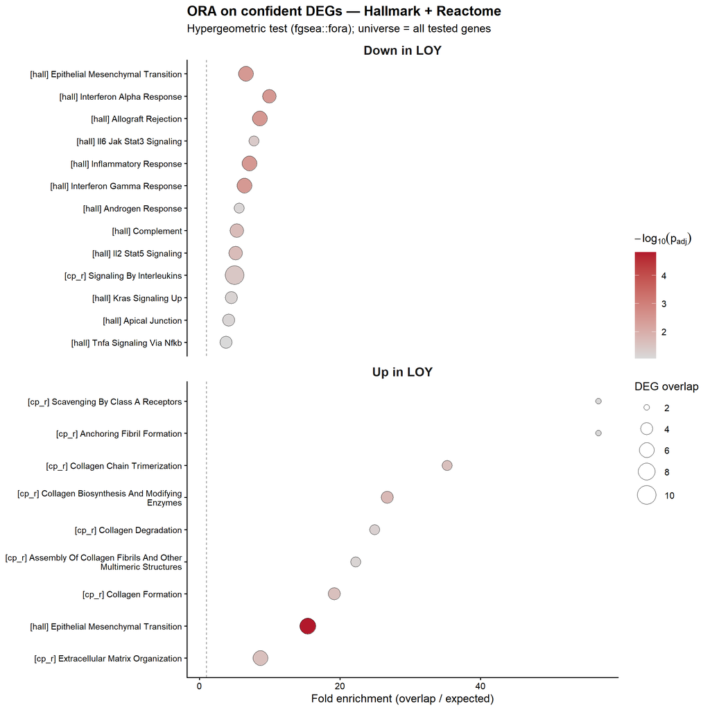

```
## Saved: robust_DEG_ORA_dotplot.(png|pdf)  [8x8 in]
```